# F1 Qualifying 2022 Clustering

Viktor Sas

2023-11-25

Introduction

In my clustering project, I am analyzing and clustering the 2022 Formula 1 Season’s qualifying results to see how the drivers and teams would fit into clusters based on their qualyifing performance. First, I am completing the cluster analysis on one single qualifying session, then I am looping through every single race weekend of the season to see the drivers and teams performance throughout the whole year.

The data was put together by toUpperCase78 from the Official Web Site of Formula1 (formula1.com): https://github.com/toUpperCase78/formula1-datasets

Importing packages:

First of all, I am loading the data from a csv file called “Formula1_2022season_qualifyingResults.csv”. I am also checking the head of the data, a summary of it and the structure. As we can see, the data need to be prepared, since the Q1,Q2,Q3 laptimes are stored as chr, but in reality this data is supposed to be some sort of timestamp, containing minutes, seconds and milliseconds.

```r
quali = read.csv("Formula1_2022season_qualifyingResults.csv")
head(quali)
```

```
##     Track Position No          Driver                 Team       Q1       Q2
## 1 Bahrain        1 16 Charles Leclerc              Ferrari 1:31.471 1:30.932
## 2 Bahrain        2  1  Max Verstappen Red Bull Racing RBPT 1:31.785 1:30.757
## 3 Bahrain        3 55    Carlos Sainz              Ferrari 1:31.567 1:30.787
## 4 Bahrain        4 11    Sergio Perez Red Bull Racing RBPT 1:32.311 1:31.008
## 5 Bahrain        5 44  Lewis Hamilton             Mercedes 1:32.285 1:31.048
## 6 Bahrain        6 77 Valtteri Bottas   Alfa Romeo Ferrari 1:31.919 1:31.717
##         Q3 Laps
## 1 1:30.558   15
## 2 1:30.681   14
## 3 1:30.687   15
## 4 1:30.921   18
## 5 1:31.238   17
## 6 1:31.560   15
```

```r
summary(quali)
```

```
##     Track             Position               No           Driver
##  Length:440         Length:440         Min.   : 1.00   Length:440
##  Class :character   Class :character   1st Qu.:10.00   Class :character
##  Mode  :character   Mode  :character   Median :20.00   Mode  :character
##                                        Mean   :24.85
##                                        3rd Qu.:44.00
##                                        Max.   :77.00
##      Team                Q1                 Q2                 Q3
##  Length:440         Length:440         Length:440         Length:440
##  Class :character   Class :character   Class :character   Class :character
##  Mode  :character   Mode  :character   Mode  :character   Mode  :character
##
##
##
##       Laps
##  Min.   : 0.00
##  1st Qu.:11.00
##  Median :16.00
##  Mean   :15.94
##  3rd Qu.:20.00
##  Max.   :31.00
```

```r
str(quali)
```

```
## 'data.frame':    440 obs. of  9 variables:
##  $ Track   : chr  "Bahrain" "Bahrain" "Bahrain" "Bahrain" ...
##  $ Position: chr  "1" "2" "3" "4" ...
##  $ No      : int  16 1 55 11 44 77 20 14 63 10 ...
##  $ Driver  : chr  "Charles Leclerc" "Max Verstappen" "Carlos Sainz" "Sergio Perez" ...
##  $ Team    : chr  "Ferrari" "Red Bull Racing RBPT" "Ferrari" "Red Bull Racing RBPT" ...
##  $ Q1      : chr  "1:31.471" "1:31.785" "1:31.567" "1:32.311" ...
##  $ Q2      : chr  "1:30.932" "1:30.757" "1:30.787" "1:31.008" ...
##  $ Q3      : chr  "1:30.558" "1:30.681" "1:30.687" "1:30.921" ...
##  $ Laps    : int  15 14 15 18 17 15 12 14 17 21 ...
```

Then again, I reconvert the milliseconds into minutes, seconds and milliseconds with lubridate’s minute and second function. But this time, as we can see, the laptimes are stored correctly as “Period”.

```r
quali$Q1_converted<- ms(quali$Q1)
quali$Q2_converted<- ms(quali$Q2)
quali$Q3_converted<- ms(quali$Q3)

quali$fastest_lap <- pmin(quali$Q1_converted,quali$Q2_converted,quali$Q3_converted,na.rm=TRUE)
sum(is.na(quali$fastest_lap))
```

```
## [1] 4
```

```r
quali2 <- quali %>% select (-c(Q1,Q2,Q3,Q1_converted,Q2_converted,Q3_converted, Laps, No ))
quali2 <- quali2[complete.cases(quali2),]

quali2$total_milliseconds <-
  (minute(quali2$fastest_lap) * 60 * 1000) +
  (second(quali2$fastest_lap) * 1000)

str(quali)
```

```
## 'data.frame':    440 obs. of  13 variables:
##  $ Track       : chr  "Bahrain" "Bahrain" "Bahrain" "Bahrain" ...
##  $ Position    : chr  "1" "2" "3" "4" ...
##  $ No          : int  16 1 55 11 44 77 20 14 63 10 ...
##  $ Driver      : chr  "Charles Leclerc" "Max Verstappen" "Carlos Sainz" "Sergio Perez" ...
##  $ Team        : chr  "Ferrari" "Red Bull Racing RBPT" "Ferrari" "Red Bull Racing RBPT" ...
##  $ Q1          : chr  "1:31.471" "1:31.785" "1:31.567" "1:32.311" ...
##  $ Q2          : chr  "1:30.932" "1:30.757" "1:30.787" "1:31.008" ...
##  $ Q3          : chr  "1:30.558" "1:30.681" "1:30.687" "1:30.921" ...
##  $ Laps        : int  15 14 15 18 17 15 12 14 17 21 ...
##  $ Q1_converted:Formal class 'Period' [package "lubridate"] with 6 slots
##   .. ..@ .Data : num  31.5 31.8 31.6 32.3 32.3 ...
##   .. ..@ year  : num  0 0 0 0 0 0 0 0 0 0 ...
##   .. ..@ month : num  0 0 0 0 0 0 0 0 0 0 ...
##   .. ..@ day   : num  0 0 0 0 0 0 0 0 0 0 ...
##   .. ..@ hour  : num  0 0 0 0 0 0 0 0 0 0 ...
##   .. ..@ minute: num  1 1 1 1 1 1 1 1 1 1 ...
##  $ Q2_converted:Formal class 'Period' [package "lubridate"] with 6 slots
##   .. ..@ .Data : num  30.9 30.8 30.8 31 31 ...
##   .. ..@ year  : num  0 0 0 0 0 0 0 0 0 0 ...
##   .. ..@ month : num  0 0 0 0 0 0 0 0 0 0 ...
##   .. ..@ day   : num  0 0 0 0 0 0 0 0 0 0 ...
##   .. ..@ hour  : num  0 0 0 0 0 0 0 0 0 0 ...
##   .. ..@ minute: num  1 1 1 1 1 1 1 1 1 1 ...
##  $ Q3_converted:Formal class 'Period' [package "lubridate"] with 6 slots
##   .. ..@ .Data : num  30.6 30.7 30.7 30.9 31.2 ...
##   .. ..@ year  : num  0 0 0 0 0 0 0 0 0 0 ...
##   .. ..@ month : num  0 0 0 0 0 0 0 0 0 0 ...
##   .. ..@ day   : num  0 0 0 0 0 0 0 0 0 0 ...
##   .. ..@ hour  : num  0 0 0 0 0 0 0 0 0 0 ...
##   .. ..@ minute: num  1 1 1 1 1 1 1 1 1 1 ...
##  $ fastest_lap :Formal class 'Period' [package "lubridate"] with 6 slots
##   .. ..@ .Data : num  30.6 30.7 30.7 30.9 31 ...
##   .. ..@ year  : num  0 0 0 0 0 0 0 0 0 0 ...
##   .. ..@ month : num  0 0 0 0 0 0 0 0 0 0 ...
##   .. ..@ day   : num  0 0 0 0 0 0 0 0 0 0 ...
##   .. ..@ hour  : num  0 0 0 0 0 0 0 0 0 0 ...
##   .. ..@ minute: num  1 1 1 1 1 1 1 1 1 1 ...
```

As a more detailed example, I take the Canadian Grand Prix’s Qualyfing session as it has the highest Hopkins score, 0,82. Which indicates that our dataset is clusterable. The clustering will be conducted on a single variable, the laptimes.

```r
can_quali <- subset(quali2, Track == "Canada")
can_quali
```

```
##      Track Position           Driver                         Team fastest_lap
## 161 Canada        1   Max Verstappen         Red Bull Racing RBPT  1M 21.299S
## 162 Canada        2  Fernando Alonso               Alpine Renault  1M 21.944S
## 163 Canada        3     Carlos Sainz                      Ferrari  1M 22.096S
## 164 Canada        4   Lewis Hamilton                     Mercedes  1M 22.891S
## 165 Canada        5  Kevin Magnussen                 Haas Ferrari   1M 22.96S
## 166 Canada        6  Mick Schumacher                 Haas Ferrari  1M 23.356S
## 167 Canada        7     Esteban Ocon               Alpine Renault  1M 23.529S
## 168 Canada        8   George Russell                     Mercedes  1M 23.557S
## 169 Canada        9 Daniel Ricciardo             McLaren Mercedes  1M 23.749S
## 170 Canada       10      Guanyu Zhou           Alfa Romeo Ferrari   1M 24.03S
## 171 Canada       11  Valtteri Bottas           Alfa Romeo Ferrari  1M 26.788S
## 172 Canada       12  Alexander Albon            Williams Mercedes  1M 26.858S
## 173 Canada       13     Sergio Perez         Red Bull Racing RBPT  1M 33.127S
## 174 Canada       14     Lando Norris             McLaren Mercedes  1M 34.066S
```

[output cut: 27 more lines]

```r
rownames(can_quali) <- can_quali[,"Driver"]

can_qualiclust <- as.data.frame(can_quali$total_milliseconds)
rownames(can_qualiclust) <- can_quali[,"Driver"]
can_qualiclust
```

```
##                  can_quali$total_milliseconds
## Max Verstappen                          81299
## Fernando Alonso                         81944
## Carlos Sainz                            82096
## Lewis Hamilton                          82891
## Kevin Magnussen                         82960
## Mick Schumacher                         83356
## Esteban Ocon                            83529
## George Russell                          83557
## Daniel Ricciardo                        83749
## Guanyu Zhou                             84030
## Valtteri Bottas                         86788
## Alexander Albon                         86858
## Sergio Perez                            93127
## Lando Norris                            94066
## Charles Leclerc                         93008
## Pierre Gasly                            94492
## Sebastian Vettel                        94512
## Lance Stroll                            95532
## Nicholas Latifi                         95660
## Yuki Tsunoda                            96575
```

```r
clusterability <- get_clust_tendency(can_qualiclust, n = nrow(can_qualiclust)-1, graph = FALSE)
clusterability$hopkins_stat
```

```
## [1] 0.8210485
```

```r
clmethods <- c("hierarchical","kmeans","pam","clara")
internal <- clValid(can_qualiclust, nClust = 2:5, clMethods = clmethods, validation = "internal", maxitems = 100)
summary(internal)
```

```
##
## Clustering Methods:
##  hierarchical kmeans pam clara
##
## Cluster sizes:
##  2 3 4 5
##
## Validation Measures:
##                                  2       3       4       5
##
## hierarchical Connectivity   2.6889  7.5468 14.0563 20.9794
##              Dunn           1.1063  0.7732  0.3735  0.5286
##              Silhouette     0.8337  0.7840  0.7004  0.6751
## kmeans       Connectivity   2.6889  7.5468 14.0563 20.9794
##              Dunn           1.1063  0.7732  0.3735  0.5286
##              Silhouette     0.8337  0.7840  0.7004  0.6751
## pam          Connectivity   2.6889  7.5468 14.4698 20.9794
##              Dunn           1.1063  0.7732  0.2229  0.5286
##              Silhouette     0.8337  0.7840  0.7587  0.6751
## clara        Connectivity   2.6889  7.5468 14.4698 20.9794
##              Dunn           1.1063  0.7732  0.2229  0.5286
##              Silhouette     0.8337  0.7840  0.7587  0.6751
##
## Optimal Scores:
##
##              Score  Method       Clusters
## Connectivity 2.6889 hierarchical 2
## Dunn         1.1063 hierarchical 2
## Silhouette   0.8337 hierarchical 2
```

The optimal number of clusters is 2, therefore I first complete the clustering with 2 clusters. However, keeping a later stage of the analysis in mind, I also cluster our data into 3 clusters.

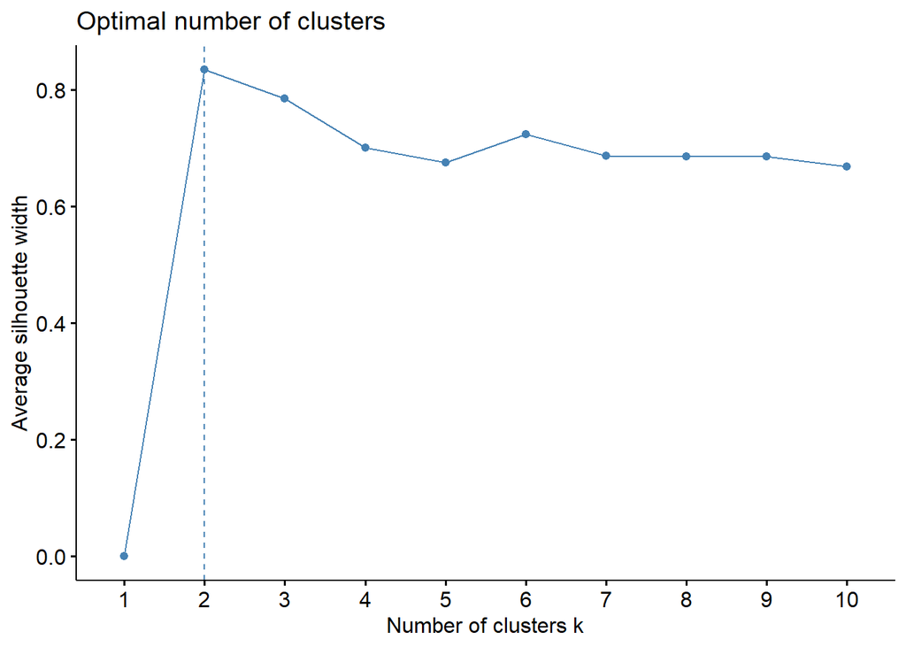

```r
fviz_nbclust(can_qualiclust, FUN = hcut, method = "silhouette")
```

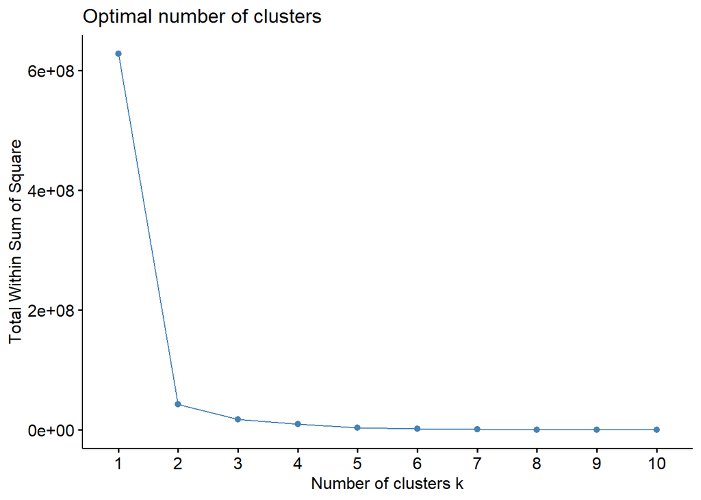

```r
fviz_nbclust(can_qualiclust, FUN = hcut, method = "wss")
```

Below you can see the results of our clustering.

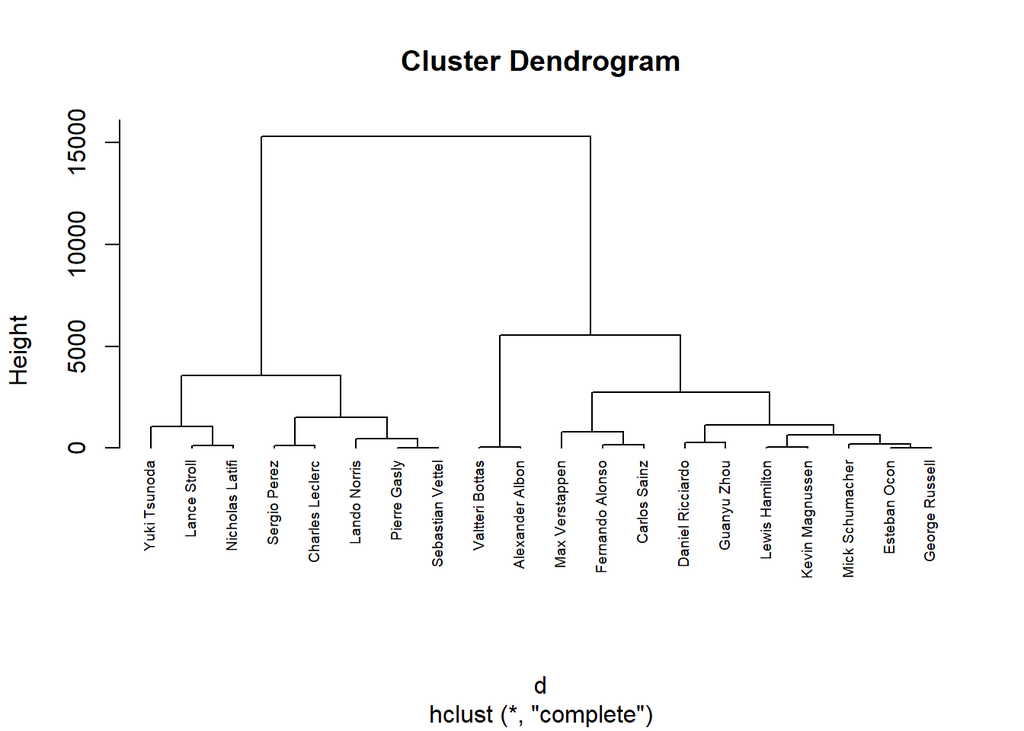

```r
d<-dist(can_qualiclust)
hc1 <- hclust(d, method = "complete" )
plot(hc1, cex = 0.6, hang = -1)
```

The agglomerative coefficient score of our clustering is 0.98 which indicates a strong clustering structure.

```r
hc2 <- agnes(can_qualiclust, method = "complete")


hc2$ac
```

```
## [1] 0.9861842
```

Results of divisive hierarchical clustering:

```r
hc3 <- diana(can_qualiclust)

hc3$dc
```

```
## [1] 0.9845313
```

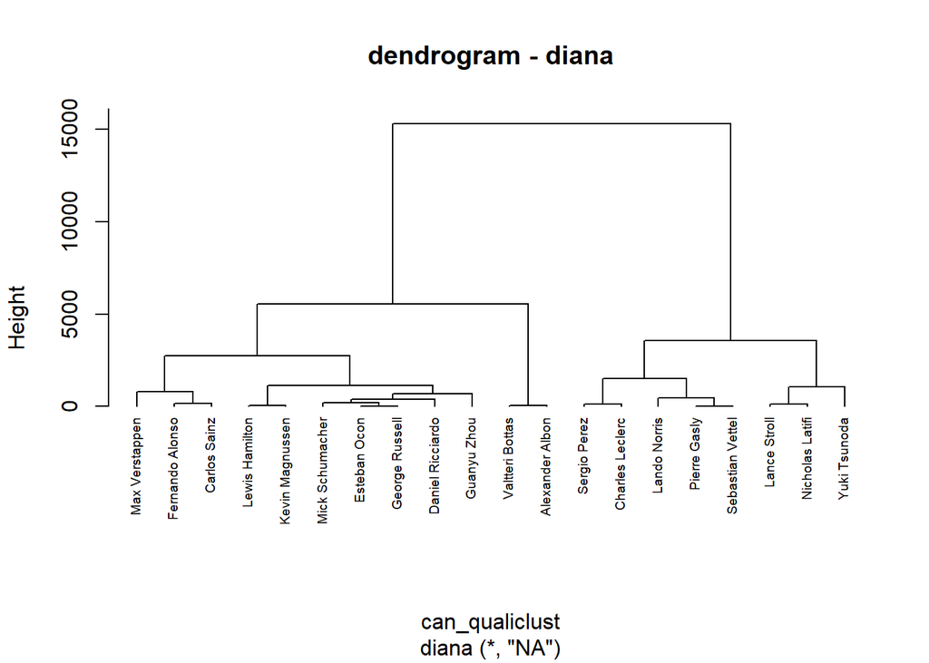

```r
pltree(hc3, cex = 0.6, hang = -1, main = "dendrogram - diana")
```

Result of clustering with Ward method:

```r
hc_ward2 <- hclust(d, method = "ward.D2" )
sub_grp2 <- cutree(hc_ward2, k = 2)
print(can_quali %>%
  mutate(cluster = sub_grp2))
```

```
##                   Track Position           Driver                         Team
## Max Verstappen   Canada        1   Max Verstappen         Red Bull Racing RBPT
## Fernando Alonso  Canada        2  Fernando Alonso               Alpine Renault
## Carlos Sainz     Canada        3     Carlos Sainz                      Ferrari
## Lewis Hamilton   Canada        4   Lewis Hamilton                     Mercedes
## Kevin Magnussen  Canada        5  Kevin Magnussen                 Haas Ferrari
## Mick Schumacher  Canada        6  Mick Schumacher                 Haas Ferrari
## Esteban Ocon     Canada        7     Esteban Ocon               Alpine Renault
## George Russell   Canada        8   George Russell                     Mercedes
## Daniel Ricciardo Canada        9 Daniel Ricciardo             McLaren Mercedes
## Guanyu Zhou      Canada       10      Guanyu Zhou           Alfa Romeo Ferrari
## Valtteri Bottas  Canada       11  Valtteri Bottas           Alfa Romeo Ferrari
## Alexander Albon  Canada       12  Alexander Albon            Williams Mercedes
## Sergio Perez     Canada       13     Sergio Perez         Red Bull Racing RBPT
## Lando Norris     Canada       14     Lando Norris             McLaren Mercedes
## Charles Leclerc  Canada       15  Charles Leclerc                      Ferrari
## Pierre Gasly     Canada       16     Pierre Gasly              AlphaTauri RBPT
## Sebastian Vettel Canada       17 Sebastian Vettel Aston Martin Aramco Mercedes
## Lance Stroll     Canada       18     Lance Stroll Aston Martin Aramco Mercedes
## Nicholas Latifi  Canada       19  Nicholas Latifi            Williams Mercedes
## Yuki Tsunoda     Canada       20     Yuki Tsunoda              AlphaTauri RBPT
##                  fastest_lap total_milliseconds cluster
## Max Verstappen    1M 21.299S              81299       1
## Fernando Alonso   1M 21.944S              81944       1
## Carlos Sainz      1M 22.096S              82096       1
## Lewis Hamilton    1M 22.891S              82891       1
## Kevin Magnussen    1M 22.96S              82960       1
## Mick Schumacher   1M 23.356S              83356       1
## Esteban Ocon      1M 23.529S              83529       1
## George Russell    1M 23.557S              83557       1
## Daniel Ricciardo  1M 23.749S              83749       1
## Guanyu Zhou        1M 24.03S              84030       1
## Valtteri Bottas   1M 26.788S              86788       1
## Alexander Albon   1M 26.858S              86858       1
## Sergio Perez      1M 33.127S              93127       2
## Lando Norris      1M 34.066S              94066       2
## Charles Leclerc   1M 33.008S              93008       2
## Pierre Gasly      1M 34.492S              94492       2
## Sebastian Vettel  1M 34.512S              94512       2
## Lance Stroll      1M 35.532S              95532       2
## Nicholas Latifi    1M 35.66S              95660       2
## Yuki Tsunoda      1M 36.575S              96575       2
```

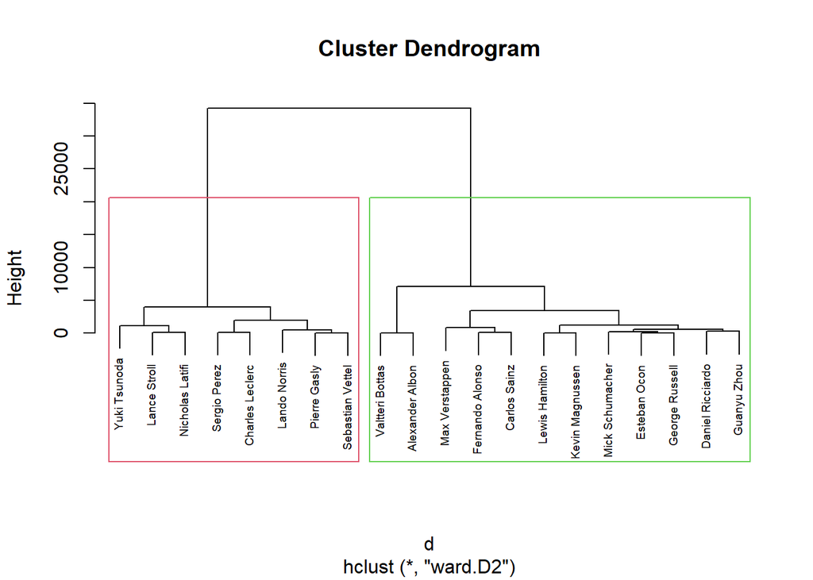

```r
plot(hc_ward2, cex = 0.6)
rect.hclust(hc_ward2, k = 2, border = 2:5)
```

```r
hc_ward3 <- hclust(d, method = "ward.D2" )
sub_grp3 <- cutree(hc_ward2, k = 3)
print(can_quali %>%
  mutate(cluster = sub_grp3))
```

```
##                   Track Position           Driver                         Team
## Max Verstappen   Canada        1   Max Verstappen         Red Bull Racing RBPT
## Fernando Alonso  Canada        2  Fernando Alonso               Alpine Renault
## Carlos Sainz     Canada        3     Carlos Sainz                      Ferrari
## Lewis Hamilton   Canada        4   Lewis Hamilton                     Mercedes
## Kevin Magnussen  Canada        5  Kevin Magnussen                 Haas Ferrari
## Mick Schumacher  Canada        6  Mick Schumacher                 Haas Ferrari
## Esteban Ocon     Canada        7     Esteban Ocon               Alpine Renault
## George Russell   Canada        8   George Russell                     Mercedes
## Daniel Ricciardo Canada        9 Daniel Ricciardo             McLaren Mercedes
## Guanyu Zhou      Canada       10      Guanyu Zhou           Alfa Romeo Ferrari
## Valtteri Bottas  Canada       11  Valtteri Bottas           Alfa Romeo Ferrari
## Alexander Albon  Canada       12  Alexander Albon            Williams Mercedes
## Sergio Perez     Canada       13     Sergio Perez         Red Bull Racing RBPT
## Lando Norris     Canada       14     Lando Norris             McLaren Mercedes
## Charles Leclerc  Canada       15  Charles Leclerc                      Ferrari
## Pierre Gasly     Canada       16     Pierre Gasly              AlphaTauri RBPT
## Sebastian Vettel Canada       17 Sebastian Vettel Aston Martin Aramco Mercedes
## Lance Stroll     Canada       18     Lance Stroll Aston Martin Aramco Mercedes
## Nicholas Latifi  Canada       19  Nicholas Latifi            Williams Mercedes
## Yuki Tsunoda     Canada       20     Yuki Tsunoda              AlphaTauri RBPT
##                  fastest_lap total_milliseconds cluster
## Max Verstappen    1M 21.299S              81299       1
## Fernando Alonso   1M 21.944S              81944       1
## Carlos Sainz      1M 22.096S              82096       1
## Lewis Hamilton    1M 22.891S              82891       1
## Kevin Magnussen    1M 22.96S              82960       1
## Mick Schumacher   1M 23.356S              83356       1
## Esteban Ocon      1M 23.529S              83529       1
## George Russell    1M 23.557S              83557       1
## Daniel Ricciardo  1M 23.749S              83749       1
## Guanyu Zhou        1M 24.03S              84030       1
## Valtteri Bottas   1M 26.788S              86788       2
## Alexander Albon   1M 26.858S              86858       2
## Sergio Perez      1M 33.127S              93127       3
## Lando Norris      1M 34.066S              94066       3
## Charles Leclerc   1M 33.008S              93008       3
## Pierre Gasly      1M 34.492S              94492       3
## Sebastian Vettel  1M 34.512S              94512       3
## Lance Stroll      1M 35.532S              95532       3
## Nicholas Latifi    1M 35.66S              95660       3
## Yuki Tsunoda      1M 36.575S              96575       3
```

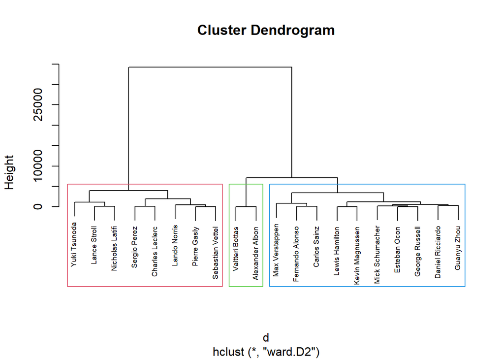

```r
plot(hc_ward3, cex = 0.6)
rect.hclust(hc_ward3, k = 3, border = 2:5)
```

```r
#average lap time per cluster
can_qualiclust$cluster <- sub_grp3
clust_average_time <- aggregate(. ~ cluster, data = can_qualiclust, FUN = mean)
clust_average_time
```

```
##   cluster can_quali$total_milliseconds
## 1       1                      82941.1
## 2       2                      86823.0
## 3       3                      94621.5
```

```r
can_quali$cluster <- sub_grp3
can_quali <- merge(can_quali,clust_average_time, by='cluster')
can_quali$distance_to_clust_avg <- (can_quali$total_milliseconds - can_quali$`can_quali$total_milliseconds`)/1000
colnames(can_quali) <- c("Cluster","Track","Position","Driver","Team","Fastest_Lap","Total_Milliseconds","Cluster_time_ms","Distance_to_clust_avg")

can_quali
```

```
##    Cluster  Track Position           Driver                         Team
## 1        1 Canada        1   Max Verstappen         Red Bull Racing RBPT
## 2        1 Canada        2  Fernando Alonso               Alpine Renault
## 3        1 Canada        3     Carlos Sainz                      Ferrari
## 4        1 Canada        4   Lewis Hamilton                     Mercedes
## 5        1 Canada        5  Kevin Magnussen                 Haas Ferrari
## 6        1 Canada        6  Mick Schumacher                 Haas Ferrari
## 7        1 Canada        7     Esteban Ocon               Alpine Renault
## 8        1 Canada        8   George Russell                     Mercedes
## 9        1 Canada        9 Daniel Ricciardo             McLaren Mercedes
## 10       1 Canada       10      Guanyu Zhou           Alfa Romeo Ferrari
## 11       2 Canada       11  Valtteri Bottas           Alfa Romeo Ferrari
## 12       2 Canada       12  Alexander Albon            Williams Mercedes
## 13       3 Canada       13     Sergio Perez         Red Bull Racing RBPT
## 14       3 Canada       14     Lando Norris             McLaren Mercedes
```

[output cut: 27 more lines]

```r
tracks <- as.list(unique(quali2$Track))
fullseason <- as.data.frame(can_quali[,c("Driver","Team")])
rownames(fullseason) <- can_quali[,"Driver"]

for (x in tracks) {
  quali_temp <- subset(quali2, Track == x)
  temp_qualiclust <- as.data.frame(quali_temp$total_milliseconds)
  rownames(temp_qualiclust) <- quali_temp[,"Driver"]
  d<-dist(temp_qualiclust)
  hc_ward_temp <- hclust(d, method = "ward.D2" )
  subgroup_temp <- cutree(hc_ward_temp, k = 3)
  subgroup_temp< - as.data.frame(subgroup_temp)
  fullseason <- merge(fullseason, subgroup_temp, by=0, all=TRUE)
  rownames(fullseason) <- fullseason[,1]
  fullseason <- fullseason[,-1]
}
fullseason<- fullseason[,-1]
names(fullseason)[2:length(names(fullseason))] <- tracks
fullseason <- fullseason[!(rownames(fullseason) %in% c('Nico Hulkenberg','Nyck De Vries')), ]
fullseason$avg_clustering_result <- rowMeans(fullseason[2:length(names(fullseason))],na.rm = TRUE)
fullseason
```

```
##                                          Team Bahrain Saudi Arabia Australia
## Alexander Albon             Williams Mercedes       3            3         3
## Carlos Sainz                          Ferrari       1            1         1
## Charles Leclerc                       Ferrari       1            1         1
## Daniel Ricciardo             McLaren Mercedes       3            2         2
## Esteban Ocon                   Alpine Renault       2            2         2
## Fernando Alonso                Alpine Renault       2            2         2
## George Russell                       Mercedes       1            2         2
## Guanyu Zhou                Alfa Romeo Ferrari       3            2         3
## Kevin Magnussen                  Haas Ferrari       2            2         3
## Lance Stroll     Aston Martin Aramco Mercedes       3            3        NA
## Lando Norris                 McLaren Mercedes       2            2         2
## Lewis Hamilton                       Mercedes       1            3         2
## Max Verstappen           Red Bull Racing RBPT       1            1         1
## Mick Schumacher                  Haas Ferrari       2            2         3
## Nicholas Latifi             Williams Mercedes       3            3         3
## Pierre Gasly                  AlphaTauri RBPT       2            2         2
## Sebastian Vettel Aston Martin Aramco Mercedes      NA           NA         3
## Sergio Perez             Red Bull Racing RBPT       1            1         1
## Valtteri Bottas            Alfa Romeo Ferrari       2            2         2
## Yuki Tsunoda                  AlphaTauri RBPT       3           NA         2
##                  Emilia Romagna Miami Spain Monaco Azerbaijan Canada
## Alexander Albon              NA     3     3      3          3      2
## Carlos Sainz                  1     1     1      1          1      1
## Charles Leclerc               1     1     1      1          1      3
## Daniel Ricciardo              2     2     2      2          2      1
## Esteban Ocon                  3    NA     2      2          2      1
## Fernando Alonso               1     2     2      2          2      1
## George Russell                2     2     1      2          2      1
## Guanyu Zhou                   1     3     2      3          2      1
## Kevin Magnussen               2     3     1      2          3      1
## Lance Stroll                  2     2     3      3          3      3
## Lando Norris                  1     2     2      1          2      3
## Lewis Hamilton                2     2     1      2          2      1
## Max Verstappen                1     1     1      1          1      1
## Mick Schumacher               2     2     2      2          3      1
## Nicholas Latifi               3     3     3      3          3      3
## Pierre Gasly                  2     2     2      3          2      3
## Sebastian Vettel              2     2     2      2          2      3
## Sergio Perez                  1     1     1      1          1      3
```

[output cut: 50 more lines]

```
## Fernando Alonso               1.727273
## George Russell                1.500000
## Guanyu Zhou                   2.272727
## Kevin Magnussen               2.227273
## Lance Stroll                  2.619048
## Lando Norris                  1.681818
## Lewis Hamilton                1.500000
## Max Verstappen                1.000000
## Mick Schumacher               2.454545
## Nicholas Latifi               2.909091
## Pierre Gasly                  2.227273
## Sebastian Vettel              2.500000
## Sergio Perez                  1.227273
## Valtteri Bottas               2.136364
## Yuki Tsunoda                  2.238095
```

After clustering every single qualifying session of the season, based on the fastest laps of each driver at each track, 2 drivers, Max Verstappen and Carlos Sainz finished the season with perfect qualifying scores, their overall cluster averages were 1.0 throughout the whole season. On the other end of the ranking, with the worst average scores we find Nicholas Latifi, Alexander Albon and Lance Stroll. In the following comparison, we are going to take a look at the qualyifing clustering results grouped by teams. It is wort to note that since Formula 1 is a technical sport, the placement into the respective clusters are not only influenced by the ability of the driver but the performance of the car also plays a huge role in achieving better lap times.

```r
teamresult <- fullseason %>%
  group_by(Team) %>%
  summarise_all(mean, na.rm = TRUE)


teamresult$avg_clustering_result <- rowMeans(teamresult[2:length(names(teamresult))],na.rm = TRUE)
teamresult <- as.data.frame(teamresult)
rownames(teamresult) <- teamresult[,1]
teamresult
```

```
##                                                      Team Bahrain Saudi Arabia
## Alfa Romeo Ferrari                     Alfa Romeo Ferrari     2.5          2.0
## AlphaTauri RBPT                           AlphaTauri RBPT     2.5          2.0
## Alpine Renault                             Alpine Renault     2.0          2.0
## Aston Martin Aramco Mercedes Aston Martin Aramco Mercedes     3.0          3.0
## Ferrari                                           Ferrari     1.0          1.0
## Haas Ferrari                                 Haas Ferrari     2.0          2.0
## McLaren Mercedes                         McLaren Mercedes     2.5          2.0
## Mercedes                                         Mercedes     1.0          2.5
## Red Bull Racing RBPT                 Red Bull Racing RBPT     1.0          1.0
## Williams Mercedes                       Williams Mercedes     3.0          3.0
##                              Australia Emilia Romagna Miami Spain Monaco
## Alfa Romeo Ferrari                 2.5            1.5   2.5   1.5    2.5
## AlphaTauri RBPT                    2.0            2.0   2.0   2.0    2.5
## Alpine Renault                     2.0            2.0   2.0   2.0    2.0
## Aston Martin Aramco Mercedes       3.0            2.0   2.0   2.5    2.5
## Ferrari                            1.0            1.0   1.0   1.0    1.0
## Haas Ferrari                       3.0            2.0   2.5   1.5    2.0
## McLaren Mercedes                   2.0            1.5   2.0   2.0    1.5
## Mercedes                           2.0            2.0   2.0   1.0    2.0
## Red Bull Racing RBPT               1.0            1.0   1.0   1.0    1.0
## Williams Mercedes                  3.0            3.0   3.0   3.0    3.0
##                              Azerbaijan Canada Great Britain Austria France
## Alfa Romeo Ferrari                  2.5    1.5           1.5     2.5    2.5
## AlphaTauri RBPT                     2.0    3.0           2.0     2.0    2.5
## Alpine Renault                      2.0    1.0           2.0     2.0    2.0
## Aston Martin Aramco Mercedes        2.5    3.0           3.0     3.0    3.0
## Ferrari                             1.0    2.0           1.0     1.0    1.0
## Haas Ferrari                        3.0    1.0           2.5     2.0    2.5
## McLaren Mercedes                    2.0    2.0           2.0     2.0    1.5
## Mercedes                            2.0    1.0           1.0     1.0    1.0
## Red Bull Racing RBPT                1.0    2.0           1.0     1.5    1.0
## Williams Mercedes                   3.0    2.5           2.0     2.5    3.0
##                              Hungary Belgium Netherlands Italy Singapore Japan
## Alfa Romeo Ferrari               1.5     3.0         2.5   2.0       3.0   2.0
## AlphaTauri RBPT                  3.0     2.5         2.0   2.0       1.0   2.5
## Alpine Renault                   1.0     2.0         2.0   2.0       2.0   2.0
## Aston Martin Aramco Mercedes     3.0     3.0         2.5   3.0       2.0   2.5
## Ferrari                          1.0     1.0         1.0   1.0       1.0   1.0
## Haas Ferrari                     2.5     3.0         2.5   3.0       1.5   3.0
```

[output cut: 11 more lines]

```
## McLaren Mercedes                       2.5    1.5    1.0       2.0
## Mercedes                               1.0    1.0    1.0       2.0
## Red Bull Racing RBPT                   1.0    1.0    1.0       1.0
## Williams Mercedes                      3.0    3.0    1.5       3.0
##                              avg_clustering_result
## Alfa Romeo Ferrari                        2.204545
## AlphaTauri RBPT                           2.227508
## Alpine Renault                            1.840862
## Aston Martin Aramco Mercedes              2.589545
## Ferrari                                   1.045455
## Haas Ferrari                              2.340909
## McLaren Mercedes                          1.863636
## Mercedes                                  1.500000
## Red Bull Racing RBPT                      1.113636
## Williams Mercedes                         2.794763
```

Based on the grouped results by teams, we can establish the ranking of the teams from “best in qualyfing” to the worst. After analyzing the whole season we find the following order: 1. Ferrari, 2. Red Bull Racing RBPT, 3. Mercedes, 4. Apline Renulat, 5. McLaren Mercedes, 6. Alfa Romeo Ferrari, 7. Alpha Tauri RBPT, 8. Haas Ferrari, 9. Aston Martin Aramco Mercedes, 10. Williams Mercedes.

An interesting fact, that the ranking made by the average cluster results over the season happens to correctly reflect the actual results. Throughout the whole season Ferrari achieved 11 pole positions, whereas Red Bull only 9. However, it is worth to note, that the main difference between the two teams’ cluster average results, and the ranking set up based on that, comes from the outliers. The number of pole positions do not have an influence on the final cluster average score, because in most cases the 1st, 2nd, 3rd, 4th places are clustered into the same cluster, since the laptimes are very close to each other. As an example, Sergio Perez’s (Red Bull Racing) bad qualifying results (13 and 11) in Canada and Hungary, made a bigger impact on the average results, as he did not manage to get into cluster number 1 with those lap times, than a pole position from Max Verstappen in Belgium.

Although in qualifying Ferrari was stronger in 2022 than Red Bull, having a stronger pace on 1 lap does not always directly lead to better results in races due to different factors, such as tyre degradation, fuel consumption, race pace, strategy, etc. That is why Red Bull won the 2022 constructor championship.